# practical machine learning assignment

Layne Lv

2016-08-03

## Introduction

This report is for course project of the **Practical Machine Learning** class. The goal of this project is to predict data, using machine learning as described in this course. This report will be evaulated by our peers and our predicitons will be checked against expected values.

### Background

Using devices such as *Jawbone Up*, *Nike FuelBand*, and *Fitbit* is now possible to collect a large amount of data about personal activity relatively inexpensively. These devices are part of the quantified self movement - a group of enthusiasts who take measurements about themselves regularly to improve their health, to find patterns in their behavior, or because they are tech geeks. One thing that people regularly do is quantify how *much* of a particular activity they do, but they rarely quantify *how well they do it*.

Six young health participants were asked to perform one set of 10 repetitions of the Unilateral Dumbbell Biceps Curl in five different fashions: exactly according to the specification (Class A), throwing the elbows to the front (Class B), lifting the dumbbell only halfway (Class C), lowering the dumbbell only halfway (Class D) and throwing the hips to the front (Class E).

**Class A corresponds to the specified execution of the exercise, while the other 4 classes correspond to common mistakes.** Participants were supervised by an experienced weight lifter to make sure the execution complied with the required expectations. The exercises were performed by six male participants aged between 20-28 years, with little weight lifting experience. We made sure that all participants could easily simulate the mistakes in a safe and controlled manner by using a relatively light dumbbell (1.25kg).

**In this project, my goal is to use data from accelerometers on the belt, forearm, arm, and dumbell of 6 participants to predict which classes of the excercise they belong to. So that we can determine whether they perfomed the barbell lifts correctly or incorrectly in 5 different ways.**

### Data

The training data for this project are available here:

https://d396qusza40orc.cloudfront.net/predmachlearn/pml-training.csv

The test data for this project are available here:

https://d396qusza40orc.cloudfront.net/predmachlearn/pml-testing.csv

## Exploratory Analysis

In this section, we will load the training data and test data at first. And then, in order to get some basic sense of these datas, we will do some exploratory analysis on them. First we load some packages.

```r
library(knitr)
library(caret)
library(ggplot2)
library(rpart)
library(randomForest)
library(gbm)
library(plyr)
library(base)
library(rattle)
```

We load the training data and test data which are already dowanloaded in my working directory.

```r
train = read.csv("pml-training.csv", na.string = c("NA", ""))
test = read.csv("pml-testing.csv", na.string = c("NA", ""))
dim(train);dim(test)
```

```
## [1] 19622   160
```

```
## [1]  20 160
```

### Summary of Data

In this section, I will evaluate the content of the data. First let us have a look about the features which the data contains.

```r
str(train, list.len = 12)
```

```
## 'data.frame':    19622 obs. of  160 variables:
##  $ X                       : int  1 2 3 4 5 6 7 8 9 10 ...
##  $ user_name               : Factor w/ 6 levels "adelmo","carlitos",..: 2 2 2 2 2 2 2 2 2 2 ...
##  $ raw_timestamp_part_1    : int  1323084231 1323084231 1323084231 1323084232 1323084232 1323084232 1323084232 1323084232 1323084232 1323084232 ...
##  $ raw_timestamp_part_2    : int  788290 808298 820366 120339 196328 304277 368296 440390 484323 484434 ...
##  $ cvtd_timestamp          : Factor w/ 20 levels "02/12/2011 13:32",..: 9 9 9 9 9 9 9 9 9 9 ...
##  $ new_window              : Factor w/ 2 levels "no","yes": 1 1 1 1 1 1 1 1 1 1 ...
##  $ num_window              : int  11 11 11 12 12 12 12 12 12 12 ...
##  $ roll_belt               : num  1.41 1.41 1.42 1.48 1.48 1.45 1.42 1.42 1.43 1.45 ...
##  $ pitch_belt              : num  8.07 8.07 8.07 8.05 8.07 8.06 8.09 8.13 8.16 8.17 ...
##  $ yaw_belt                : num  -94.4 -94.4 -94.4 -94.4 -94.4 -94.4 -94.4 -94.4 -94.4 -94.4 ...
##  $ total_accel_belt        : int  3 3 3 3 3 3 3 3 3 3 ...
##  $ kurtosis_roll_belt      : Factor w/ 396 levels "-0.016850","-0.021024",..: NA NA NA NA NA NA NA NA NA NA ...
##   [list output truncated]
```

Above is the structure of the training data. Because there are so many features, I just show the first 12 lines of the structure to save some space. By looking the data, we can find out it contains: `(x)`, `(user_name)`, `(raw_timestamp_part_1)`, `(raw_timestamp_part_2)`, `(cvtd_timestamp)`, `(new_window)`, `(num_window)`, `(classe)`, and 52 features collected from different accelerometers sensors. Within these features, `(classe)` is the *outcome* that we have to predict, others are the *predictors* we may use to predict the outcome.

### Predictors Plotting

To have a more intuitive understanding about the predictors, I will show a scatter plot of the 7 features we discussed above.

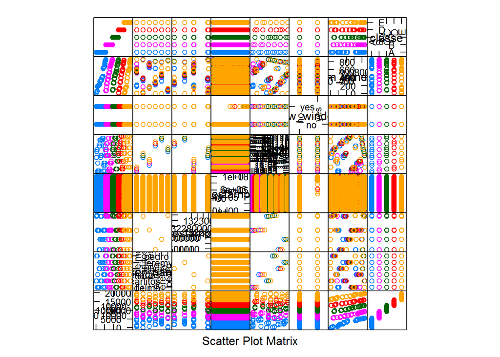

```r
featurePlot(x = train[, c("X", "user_name", "raw_timestamp_part_1", "raw_timestamp_part_2", "cvtd_timestamp", "new_window", "num_window", "classe")], y = train$classe, plot = "pairs")
```

## Data Preprocessing

In this section, I will do some data preprocessing to prepare the data for the machine learning process. Not all of the features are suitable for the machine learning model, so I will do some feature selection.

### Feature Selection

Through the summary and scatter plot, I have discovered some issues in the data, which may cause some problems in the machine learning process. So I will select some featurs to improve the accuracy when I use the learning model, and it will not waste so much time. These problems are listed as belows:

- Some features like `(x)` or `(use_name)` are not relative to our research. Though it may shows a strong relationship between the outcome it is meaningless.
- For the other sensor features, all of them should be numeric type. However, some of the features are shown as factor type. For example, `(kurtosis_roll_belt)`
- There are lots of missing values (NA) in some of the features. For example, `(kurtosis_roll_belt)`

To solve these problems, first I’ll remove all of the features which contain NA and then I will convert all of the values collected from accelerometers sensors to numeric type, hsolving the factor problem. This will enable me to test the data again for the prediction in future.

```r
num_na <- 0
for(i in 7 : dim(train)[2] - 1){
    if(class(train[, i]) != "numeric"){
        train[, i] <- as.numeric(as.character(train[, i]))
    }
    if(sum(is.na(train[, i])) != 0){
         num_na <- c(num_na, i)
    }
}
num_na <- num_na[-1]
train <- train[, -num_na]

num_na <- 0
for(i in 7 : dim(test)[2] - 1){
    if(class(test[, i]) != "numeric"){
        test[, i] <- as.numeric(as.character(test[, i]))
    }
    if(sum(is.na(test[, i])) != 0){
        num_na <- c(num_na, i)
    }
}
num_na <- num_na[-1]
test <- test[, -num_na]

str(train, list.len = 12)
```

```
## 'data.frame':    19622 obs. of  59 variables:
##  $ X                   : int  1 2 3 4 5 6 7 8 9 10 ...
##  $ user_name           : Factor w/ 6 levels "adelmo","carlitos",..: 2 2 2 2 2 2 2 2 2 2 ...
##  $ raw_timestamp_part_1: int  1323084231 1323084231 1323084231 1323084232 1323084232 1323084232 1323084232 1323084232 1323084232 1323084232 ...
##  $ raw_timestamp_part_2: int  788290 808298 820366 120339 196328 304277 368296 440390 484323 484434 ...
##  $ cvtd_timestamp      : Factor w/ 20 levels "02/12/2011 13:32",..: 9 9 9 9 9 9 9 9 9 9 ...
##  $ num_window          : num  11 11 11 12 12 12 12 12 12 12 ...
##  $ roll_belt           : num  1.41 1.41 1.42 1.48 1.48 1.45 1.42 1.42 1.43 1.45 ...
##  $ pitch_belt          : num  8.07 8.07 8.07 8.05 8.07 8.06 8.09 8.13 8.16 8.17 ...
##  $ yaw_belt            : num  -94.4 -94.4 -94.4 -94.4 -94.4 -94.4 -94.4 -94.4 -94.4 -94.4 ...
##  $ total_accel_belt    : num  3 3 3 3 3 3 3 3 3 3 ...
##  $ gyros_belt_x        : num  0 0.02 0 0.02 0.02 0.02 0.02 0.02 0.02 0.03 ...
##  $ gyros_belt_y        : num  0 0 0 0 0.02 0 0 0 0 0 ...
##   [list output truncated]
```

Then I have also shown the 12 lines of the structure of the training data. In the next step, I will remove `(x)`, `(user_name)`, `(raw_timestamp_part_1)`, `(raw_timestamp_part_2)`, `(cvtd_timestamp)`, `(num_window)` 6 features, since these features are meaningless for the learning process.

```r
train <- train[, -c(1, 2, 3, 4, 5, 6)]
```

At last, I have checked that whether there are any features has zero variance. The answer is none.

```r
nearZeroVar(train, saveMetrics = TRUE)
```

```
##                      freqRatio percentUnique zeroVar   nzv
## roll_belt             1.101904     6.7781062   FALSE FALSE
## pitch_belt            1.036082     9.3772296   FALSE FALSE
## yaw_belt              1.058480     9.9734991   FALSE FALSE
## total_accel_belt      1.063160     0.1477933   FALSE FALSE
## gyros_belt_x          1.058651     0.7134849   FALSE FALSE
## gyros_belt_y          1.144000     0.3516461   FALSE FALSE
## gyros_belt_z          1.066214     0.8612782   FALSE FALSE
## accel_belt_x          1.055412     0.8357966   FALSE FALSE
## accel_belt_y          1.113725     0.7287738   FALSE FALSE
## accel_belt_z          1.078767     1.5237998   FALSE FALSE
## magnet_belt_x         1.090141     1.6664968   FALSE FALSE
## magnet_belt_y         1.099688     1.5187035   FALSE FALSE
## magnet_belt_z         1.006369     2.3290184   FALSE FALSE
## roll_arm             52.338462    13.5256345   FALSE FALSE
## pitch_arm            87.256410    15.7323412   FALSE FALSE
## yaw_arm              33.029126    14.6570176   FALSE FALSE
## total_accel_arm       1.024526     0.3363572   FALSE FALSE
## gyros_arm_x           1.015504     3.2769341   FALSE FALSE
## gyros_arm_y           1.454369     1.9162165   FALSE FALSE
## gyros_arm_z           1.110687     1.2638875   FALSE FALSE
## accel_arm_x           1.017341     3.9598410   FALSE FALSE
## accel_arm_y           1.140187     2.7367241   FALSE FALSE
## accel_arm_z           1.128000     4.0362858   FALSE FALSE
## magnet_arm_x          1.000000     6.8239731   FALSE FALSE
## magnet_arm_y          1.056818     4.4439914   FALSE FALSE
## magnet_arm_z          1.036364     6.4468454   FALSE FALSE
## roll_dumbbell         1.022388    84.2065029   FALSE FALSE
## pitch_dumbbell        2.277372    81.7449801   FALSE FALSE
## yaw_dumbbell          1.132231    83.4828254   FALSE FALSE
## total_accel_dumbbell  1.072634     0.2191418   FALSE FALSE
## gyros_dumbbell_x      1.003268     1.2282132   FALSE FALSE
## gyros_dumbbell_y      1.264957     1.4167771   FALSE FALSE
## gyros_dumbbell_z      1.060100     1.0498420   FALSE FALSE
## accel_dumbbell_x      1.018018     2.1659362   FALSE FALSE
## accel_dumbbell_y      1.053061     2.3748853   FALSE FALSE
## accel_dumbbell_z      1.133333     2.0894914   FALSE FALSE
## magnet_dumbbell_x     1.098266     5.7486495   FALSE FALSE
## magnet_dumbbell_y     1.197740     4.3012945   FALSE FALSE
## magnet_dumbbell_z     1.020833     3.4451126   FALSE FALSE
## roll_forearm         11.589286    11.0895933   FALSE FALSE
## pitch_forearm        65.983051    14.8557741   FALSE FALSE
## yaw_forearm          15.322835    10.1467740   FALSE FALSE
## total_accel_forearm   1.128928     0.3567424   FALSE FALSE
## gyros_forearm_x       1.059273     1.5187035   FALSE FALSE
## gyros_forearm_y       1.036554     3.7763735   FALSE FALSE
## gyros_forearm_z       1.122917     1.5645704   FALSE FALSE
## accel_forearm_x       1.126437     4.0464784   FALSE FALSE
## accel_forearm_y       1.059406     5.1116094   FALSE FALSE
## accel_forearm_z       1.006250     2.9558659   FALSE FALSE
## magnet_forearm_x      1.012346     7.7667924   FALSE FALSE
## magnet_forearm_y      1.246914     9.5403119   FALSE FALSE
## magnet_forearm_z      1.000000     8.5771073   FALSE FALSE
## classe                1.469581     0.0254816   FALSE FALSE
```

```r
str(train, list.len = 12)
```

```
## 'data.frame':    19622 obs. of  53 variables:
##  $ roll_belt           : num  1.41 1.41 1.42 1.48 1.48 1.45 1.42 1.42 1.43 1.45 ...
##  $ pitch_belt          : num  8.07 8.07 8.07 8.05 8.07 8.06 8.09 8.13 8.16 8.17 ...
##  $ yaw_belt            : num  -94.4 -94.4 -94.4 -94.4 -94.4 -94.4 -94.4 -94.4 -94.4 -94.4 ...
##  $ total_accel_belt    : num  3 3 3 3 3 3 3 3 3 3 ...
##  $ gyros_belt_x        : num  0 0.02 0 0.02 0.02 0.02 0.02 0.02 0.02 0.03 ...
##  $ gyros_belt_y        : num  0 0 0 0 0.02 0 0 0 0 0 ...
##  $ gyros_belt_z        : num  -0.02 -0.02 -0.02 -0.03 -0.02 -0.02 -0.02 -0.02 -0.02 0 ...
##  $ accel_belt_x        : num  -21 -22 -20 -22 -21 -21 -22 -22 -20 -21 ...
##  $ accel_belt_y        : num  4 4 5 3 2 4 3 4 2 4 ...
##  $ accel_belt_z        : num  22 22 23 21 24 21 21 21 24 22 ...
##  $ magnet_belt_x       : num  -3 -7 -2 -6 -6 0 -4 -2 1 -3 ...
##  $ magnet_belt_y       : num  599 608 600 604 600 603 599 603 602 609 ...
##   [list output truncated]
```

### Cross Validation

Cross validation is used to *avoid overfitting*, and estimate *out of sample error*. There are numerous different models of cross validation. In this project, I am using the **K-Fold** cross validation. To balance the bias-variance trade off, I choose **k = 10**.

```r
set.seed(999)

folds <- createFolds(y = train$classe, k = 10, list = TRUE, returnTrain = TRUE)

training <- list(train[folds[[1]], ])
validing <- list(train[-folds[[1]], ])

for(i in 1 : 10){training[[i]] <- train[folds[[i]], ]}
for(i in 1 : 10){validing[[i]] <- train[-folds[[i]], ]}

sapply(folds, length)
```

```
## Fold01 Fold02 Fold03 Fold04 Fold05 Fold06 Fold07 Fold08 Fold09 Fold10
##  17659  17659  17660  17660  17660  17660  17661  17659  17661  17659
```

I created 10 folds within the original training data. Above shows the size of each the 10 folds. I created a list called `(training)` contained all of the 10 datasets for *training*, while I created a list called `(validing)` which preserved all of the 10 datasets for *cross validation*.

## Machine Learning

### Bagging

```r
set.seed(999)
modFit_rpart <- rpart(classe ~ ., method = "class", data = training[[1]])
```

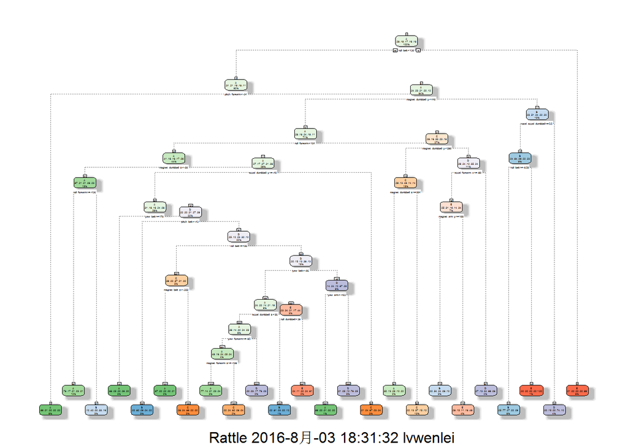

```r
fancyRpartPlot(modFit_rpart)
```

This figure shows the structure of the tree.

```r
pred_rpart <- predict(modFit_rpart, validing[[1]], type = "class")
confusionMatrix(validing[[1]]$classe, pred_rpart)
```

```
## Confusion Matrix and Statistics
##
##           Reference
## Prediction   A   B   C   D   E
##          A 509  17  15   6  11
##          B  64 224  48  31  13
##          C  10  31 268  25   8
##          D  11  31  58 195  27
##          E  16  24  44  21 256
##
## Overall Statistics
##
##                Accuracy : 0.7397
##                  95% CI : (0.7197, 0.759)
##     No Information Rate : 0.3107
##     P-Value [Acc > NIR] : < 2.2e-16
##
##                   Kappa : 0.6698
##  Mcnemar's Test P-Value : 2.55e-12
##
## Statistics by Class:
##
##                      Class: A Class: B Class: C Class: D Class: E
## Sensitivity            0.8344   0.6850   0.6189  0.70144   0.8127
## Specificity            0.9638   0.9046   0.9516  0.92463   0.9363
## Pos Pred Value         0.9122   0.5895   0.7836  0.60559   0.7091
## Neg Pred Value         0.9281   0.9349   0.8982  0.94942   0.9632
## Prevalence             0.3107   0.1666   0.2206  0.14162   0.1605
## Detection Rate         0.2593   0.1141   0.1365  0.09934   0.1304
## Detection Prevalence   0.2843   0.1936   0.1742  0.16403   0.1839
## Balanced Accuracy      0.8991   0.7948   0.7853  0.81303   0.8745
```

This is the *confusion matrix* of the prediction. We can see from this matrix, the accuracy of this prediction is **73.97%**. Next I will use the all 10 training set and cross validation set to calculate the expected out of sample error.

```r
error_rpart <- rep(NA, 10)
set.seed(999)
for(i in 1 : 10){
    modFit_rpart <- rpart(classe ~ ., method = "class", data = training[[i]])
    pred_rpart <- predict(modFit_rpart, validing[[i]], type = "class")
    error_rpart[i] <- 1 - confusionMatrix(validing[[i]]$classe, pred_rpart)$overall[1]
}

OsamError_rpart <- sqrt(mean(error_rpart^2))

print(error_rpart)
```

```
##  [1] 0.2603158 0.2363729 0.2716616 0.2487258 0.2451580 0.2599388 0.2575217
##  [8] 0.2542028 0.2723100 0.2679572
```

These shows the error rate of every train - cross validation sets.

```r
print(OsamError_rpart)
```

```
## [1] 0.2576552
```

### Random Forest

Random Forest provide an improvement over bagged tree by *decorrelating* the trees. Random forest will not use all of the predictors after a split. It will use a subset of the predictors. And this will continuous decrease the variance of the outcome. First, I will choose one of the training - validing set to present the result of random forest. Here I use `(mtry = 30)`, indicates that there are 30 predictors will be considered for each split of the tree.

```r
set.seed(999)
modFit_rf <- randomForest(classe ~ ., data = training[[1]], mtry = 30, importance = TRUE)
```

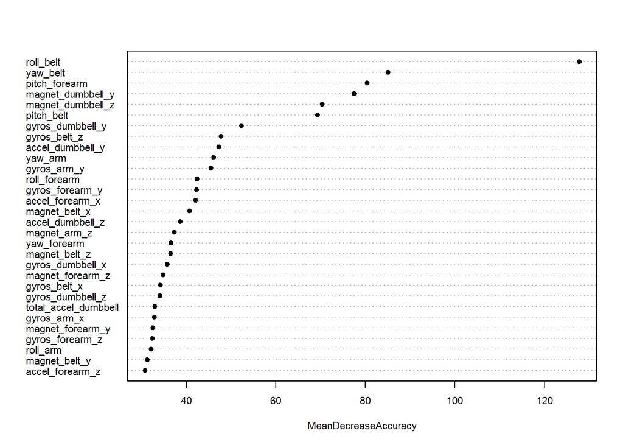

```r
varImpPlot(modFit_rf, type = 1, pch = 19, col = 1, cex = 0.7, main = "")
```

This is the plot of **Variable Importance**. For this train dataset, **roll_belt** has the variable that has the most importance.

```r
pred_rf <- predict(modFit_rf, validing[[1]])
confusionMatrix(validing[[1]]$classe, pred_rf)
```

```
## Confusion Matrix and Statistics
##
##           Reference
## Prediction   A   B   C   D   E
##          A 558   0   0   0   0
##          B   2 378   0   0   0
##          C   0   2 338   2   0
##          D   0   0   2 319   1
##          E   0   0   2   0 359
##
## Overall Statistics
##
##                Accuracy : 0.9944
##                  95% CI : (0.99, 0.9972)
##     No Information Rate : 0.2853
##     P-Value [Acc > NIR] : < 2.2e-16
##
##                   Kappa : 0.9929
##  Mcnemar's Test P-Value : NA
##
## Statistics by Class:
##
##                      Class: A Class: B Class: C Class: D Class: E
## Sensitivity            0.9964   0.9947   0.9883   0.9938   0.9972
## Specificity            1.0000   0.9987   0.9975   0.9982   0.9988
## Pos Pred Value         1.0000   0.9947   0.9883   0.9907   0.9945
## Neg Pred Value         0.9986   0.9987   0.9975   0.9988   0.9994
## Prevalence             0.2853   0.1936   0.1742   0.1635   0.1834
## Detection Rate         0.2843   0.1926   0.1722   0.1625   0.1829
## Detection Prevalence   0.2843   0.1936   0.1742   0.1640   0.1839
## Balanced Accuracy      0.9982   0.9967   0.9929   0.9960   0.9980
```

This is the *confusion matrix* of the prediction. We can see from this matrix, the accuracy of this prediction is **99.44%**. Next I will use the all 10 training set and cross validation set to calculate the expected out of sample error.

```r
error_rf <- rep(NA, 10)
set.seed(999)
for(i in 1 : 10){
    modFit_rf <- randomForest(classe ~ ., data = training[[i]], mtry = 30, importance = FALSE)
    pred_rf <- predict(modFit_rf, validing[[i]], type = "class")
    error_rf[i] <- 1 - confusionMatrix(validing[[i]]$classe, pred_rf)$overall[1]
}

OsamError_rf <- sqrt(mean(error_rf^2))

print(error_rf)
```

```
##  [1] 0.006113092 0.002037697 0.005096840 0.006625892 0.005606524
##  [6] 0.005606524 0.004079551 0.005603668 0.008159102 0.007131941
```

These shows the error rate of every train - cross validation sets.

```r
print(OsamError_rf)
```

```
## [1] 0.00582879
```

The expected *Root Mean Square* out of sample error of the random forest method is **0.0058**, which is much smaller compare to the bagging model. So next I will try boosting, to find out which model has the most accuracy or the smallest out of sample error on this dataset.

### Boosting

Boosting is another approach for improving the predictions results from a decision tree. It works in a similar way as random forest, which is each tree is grown using information from previously grown trees. Boosting does not involve bootstrap sampling, instead each tree is fit on a modified version of the original dataset.

```r
set.seed(999)
modFit_gbm <- gbm(classe ~ ., data = training[[1]], distribution = "multinomial", n.trees = 2000, shrinkage = 0.01, interaction.depth = 4, verbose = FALSE)
```

Here I use gbm package to train the data. `(distribution = "multinomial")` This means that I am using multinomial method to train a multiple classification problem. `(n.trees = 2000)` indicates that I am using 2000 trees to train my data. `(shrinkage = 0.01)` shrinkage parameter controls the rate at which boosting learns. Smaller number of shrinkage parameter will lead to more accuracy but will cost more time. `(interaction depth = 4)` means number of splits in each tree. Here I choose the number of splits equal to 4.

```r
pred_gbm <- predict(modFit_gbm, validing[[1]], n.trees = gbm.perf(modFit_gbm, plot.it = FALSE), type = "response")
```

```
## Using OOB method...
```

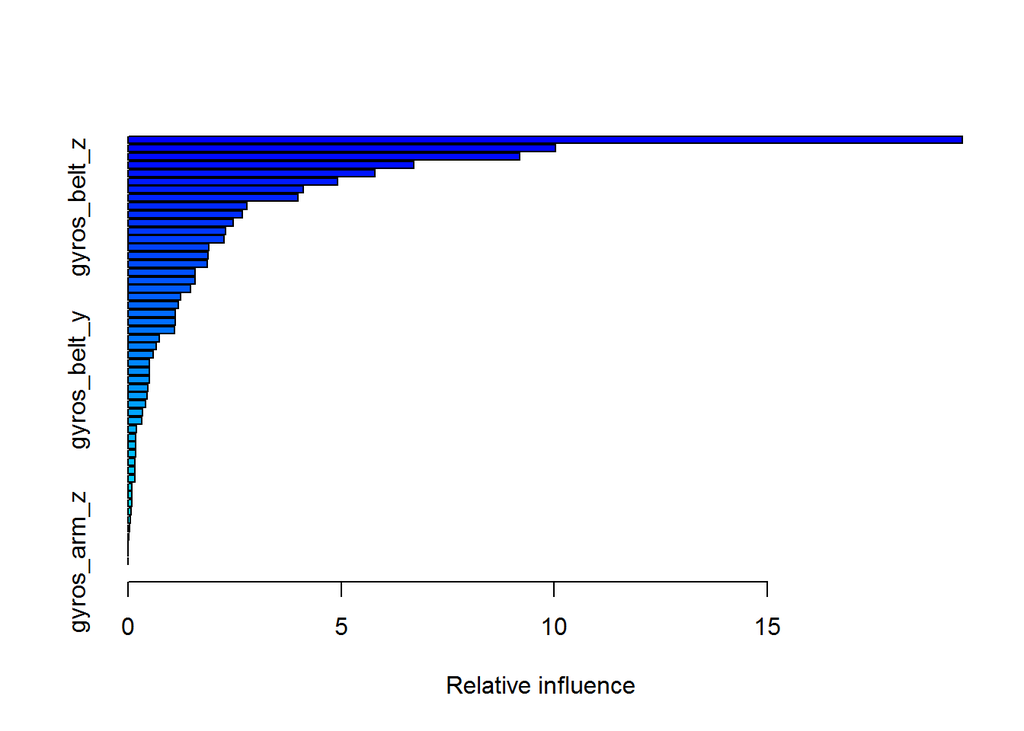

```r
summary(modFit_gbm)
```

```r
pred_gbm_value <- rep(NA, dim(validing[[1]])[1])
for(i in 1 : dim(pred_gbm)[1]){
    pred_gbm_value[i] <- LETTERS[as.numeric(which.max(pred_gbm[, , 1][i, ]))]
}
confusionMatrix(validing[[1]]$classe, pred_gbm_value)
```

```
## Confusion Matrix and Statistics
##
##           Reference
## Prediction   A   B   C   D   E
##          A 554   2   1   0   1
##          B   7 368   5   0   0
##          C   0   8 330   4   0
##          D   0   1   5 313   3
##          E   0   2   4   4 351
##
## Overall Statistics
##
##                Accuracy : 0.9761
##                  95% CI : (0.9683, 0.9824)
##     No Information Rate : 0.2858
##     P-Value [Acc > NIR] : < 2.2e-16
##
##                   Kappa : 0.9697
##  Mcnemar's Test P-Value : NA
##
## Statistics by Class:
##
##                      Class: A Class: B Class: C Class: D Class: E
## Sensitivity            0.9875   0.9659   0.9565   0.9751   0.9887
## Specificity            0.9971   0.9924   0.9926   0.9945   0.9938
## Pos Pred Value         0.9928   0.9684   0.9649   0.9720   0.9723
## Neg Pred Value         0.9950   0.9918   0.9907   0.9951   0.9975
## Prevalence             0.2858   0.1941   0.1758   0.1635   0.1808
## Detection Rate         0.2822   0.1875   0.1681   0.1594   0.1788
## Detection Prevalence   0.2843   0.1936   0.1742   0.1640   0.1839
## Balanced Accuracy      0.9923   0.9791   0.9746   0.9848   0.9913
```

Because the prediction result is the probability of each class be choosed. So to calculate the confusion matrix, I have chosen the class which has the highest probablity within every samples. The above code chunk also shows that the accuracy is **97.61%**.

```r
set.seed(999)
error_gbm = rep(NA, 5)
for(i in 1 : 5){
    modFit_gbm <- gbm(classe ~ ., data = training[[i]], distribution = "multinomial", n.trees = 2000, shrinkage = 0.01, interaction.depth = 4, verbose = FALSE)
    pred_gbm <- predict(modFit_gbm, validing[[i]], n.trees = 2000, type = "response")
    pred_gbm_value <- rep(NA, dim(validing[[i]])[1])
    for(j in 1 : dim(pred_gbm)[1]){
        pred_gbm_value[j] <- LETTERS[as.numeric(which.max(pred_gbm[, , 1][j, ]))]
    }
    error_gbm[i] <- 1 - confusionMatrix(validing[[i]]$classe, pred_gbm_value)$overall[1]
}

OsamError_gbm <- mean(error_gbm^2)

print(error_gbm)
```

```
## [1] 0.023942944 0.009169638 0.012232416 0.015290520 0.016819572
```

At last, I have calculated the expected out of sample error. Because the memory limited of my current computer, I could not complete calculation using all 10 training validation pairs. So I have chosen the first 5 training validation pairs to expect the out of sample error. Above shows the error rate of all 5 pairs.

```r
print(sqrt(OsamError_gbm))
```

```
## [1] 0.01627069
```

The expected *Root Mean Square* out of sample error of using boosting model on this dataset is **0.0162**

## Conclusion

In this project, I have used three machine learning classification models *Bagging*, *Random Forest*, and *Boosting* to classify five class of movement using the data collected from accelerometers sensors. Also I use the *K fold* cross validation method to calculated the expected *out of sample error*. The results are listed as follows,

- Bagging ~ expected out of sample error: **0.2576**
- Random Forest ~ expected out of sample error: **0.0058**
- Boosting ~ expected out of sample error: **0.0162**

To sum up, **Random Forest** model has the smallest expected out of sample error. The second model is **Boosting**. **Bagging** has the biggest expected out of sample error on this dataset.

### Predict Test Set

Finally, I will present the three prediction results on the test set using the above three method.

```r
## Prediction result using Bagging model
as.character(pred_rpart <- predict(modFit_rpart, test, type = "class"))
```

```
##  [1] "B" "A" "B" "A" "A" "C" "D" "A" "A" "A" "C" "B" "C" "A" "E" "E" "A"
## [18] "A" "A" "B"
```

```r
## Prediction result using Random Forest model
as.character(pred_rf <- predict(modFit_rf, test))
```

```
##  [1] "B" "A" "B" "A" "A" "E" "D" "B" "A" "A" "B" "C" "B" "A" "E" "E" "A"
## [18] "B" "B" "B"
```

```r
## Prediction result using Boosting model
pred_gbm <- predict(modFit_gbm, test, n.trees = 2000, type = "response")
pred_gbm_value <- rep(NA, dim(test)[1])
for(i in 1 : dim(pred_gbm)[1]){
    pred_gbm_value[i] <- LETTERS[as.numeric(which.max(pred_gbm[, , 1][i, ]))]
}
as.character(pred_gbm_value)
```

```
##  [1] "B" "A" "B" "A" "A" "E" "D" "B" "A" "A" "B" "C" "B" "A" "E" "E" "A"
## [18] "B" "B" "B"
```

The **top one** is the restuls for the *Bagging* model, while the **middle one** is for the *Random Forest* model. Finally, the **last one** is for the *Boosting* model.